# German Rental Advanced Analysis and predction Models Part 1: Feature Analysis and Engeneering

Based on the Kaggle immo_data dataset. More informations can be found here: https://www.kaggle.com/datasets/corrieaar/apartment-rental-offers-in-germany

packages install

```r
mirror = "http://cran.us.r-project.org"
#install.packages("moments", repos=mirror)
#install.packages("ggplot2", repos=mirror)
#install.packages("car", repos=mirror)
#install.packages("MASS", repos=mirror)
#install.packages("dummies", repos=mirror)
```

packages loads

```r
library("moments")
library("ggplot2")
library("car")
library("MASS")
library("dummies")
```

# Preparing the Data

```r
data_raw = read.csv('immo_data_raw.csv')
head(data_raw)
```

|  | regio1 | serviceCharge | heatingType | telekomTvOffer | telekomHybridUploadSpeed | newlyConst | balcony | picturecount | pricetrend | telekomUploadSpeed | totalRent | yearConstructed | scoutId | noParkSpaces | firingTypes | hasKitchen | geo_bln | cellar | yearConstructedRange | baseRent | houseNumber | livingSpace | geo_krs | condition | interiorQual | petsAllowed | street | streetPlain | lift | … |
| --- | --- | --- | --- | --- | --- | --- | --- | --- | --- | --- | --- | --- | --- | --- | --- | --- | --- | --- | --- | --- | --- | --- | --- | --- | --- | --- | --- | --- | --- | --- |
| 1 | Nordrhein_Westfalen | 245.00 | central_heating | ONE_YEAR_FREE | NA | FALSE | FALSE | 6 | 4.62 | 10.0 | 840 | 1965 | 96107057 | 1 | oil | FALSE | Nordrhein_Westfalen | TRUE | 2 | 595.0 | 244 | 86.00 | Dortmund | well_kept | normal | NA | Sch&uuml;ruferstra&szlig;e | Schüruferstraße | FALSE | … |
| 2 | Rheinland_Pfalz | 134.00 | self_contained_central_heating | ONE_YEAR_FREE | NA | FALSE | TRUE | 8 | 3.47 | 10.0 | NA | 1871 | 111378734 | 2 | gas | FALSE | Rheinland_Pfalz | FALSE | 1 | 800.0 | NA | 89.00 | Rhein_Pfalz_Kreis | refurbished | normal | no | no_information | NA | FALSE | … |
| 3 | Sachsen | 255.00 | floor_heating | ONE_YEAR_FREE | 10 | TRUE | TRUE | 8 | 2.72 | 2.4 | 1300 | 2019 | 113147523 | 1 | NA | FALSE | Sachsen | TRUE | 9 | 965.0 | 4 | 83.80 | Dresden | first_time_use | sophisticated | NA | Turnerweg | Turnerweg | TRUE | … |
| 4 | Sachsen | 58.15 | district_heating | ONE_YEAR_FREE | NA | FALSE | TRUE | 9 | 1.53 | 40.0 | NA | 1964 | 108890903 | NA | district_heating | FALSE | Sachsen | FALSE | 2 | 343.0 | 35 | 58.15 | Mittelsachsen_Kreis | NA | NA | NA | Gl&uuml;ck-Auf-Stra&szlig;e | Glück-Auf-Straße | FALSE | … |
| 5 | Bremen | 138.00 | self_contained_central_heating | NA | NA | FALSE | TRUE | 19 | 2.46 | NA | 903 | 1950 | 114751222 | NA | gas | FALSE | Bremen | FALSE | 1 | 765.0 | 10 | 84.97 | Bremen | refurbished | NA | NA | Hermann-Henrich-Meier-Allee | Hermann-Henrich-Meier-Allee | FALSE | … |
| 6 | Schleswig_Holstein | 142.00 | gas_heating | NONE | NA | FALSE | TRUE | 5 | 4.48 | 2.4 | NA | 1999 | 115531145 | NA | gas | TRUE | Schleswig_Holstein | FALSE | 5 | 315.2 | 1e | 53.43 | Schleswig_Flensburg_Kreis | well_kept | NA | no | Hardeseiche | Hardeseiche | FALSE | … |

Since I am interested in rental price predictions the first thing is to just drop all rows where this information is not given. One could impute these values one way or another but to keep the accuracy on the data as high as possible I am just going to removes these entries from the data.

```r
rental_na = which(is.na(data_raw$totalRent))
removal_fraction = length(rental_na) / length(data_raw$totalRent)
removal_fraction
```

```
[1] 0.1507049
```

```r
data_raw = data_raw[-rental_na, ]
head(data_raw)
```

|  | regio1 | serviceCharge | heatingType | telekomTvOffer | telekomHybridUploadSpeed | newlyConst | balcony | picturecount | pricetrend | telekomUploadSpeed | totalRent | yearConstructed | scoutId | noParkSpaces | firingTypes | hasKitchen | geo_bln | cellar | yearConstructedRange | baseRent | houseNumber | livingSpace | geo_krs | condition | interiorQual | petsAllowed | street | streetPlain | lift | … |
| --- | --- | --- | --- | --- | --- | --- | --- | --- | --- | --- | --- | --- | --- | --- | --- | --- | --- | --- | --- | --- | --- | --- | --- | --- | --- | --- | --- | --- | --- | --- |
| 1 | Nordrhein_Westfalen | 245 | central_heating | ONE_YEAR_FREE | NA | FALSE | FALSE | 6 | 4.62 | 10.0 | 840.00 | 1965 | 96107057 | 1 | oil | FALSE | Nordrhein_Westfalen | TRUE | 2 | 595.00 | 244 | 86.00 | Dortmund | well_kept | normal | NA | Sch&uuml;ruferstra&szlig;e | Schüruferstraße | FALSE | … |
| 3 | Sachsen | 255 | floor_heating | ONE_YEAR_FREE | 10 | TRUE | TRUE | 8 | 2.72 | 2.4 | 1300.00 | 2019 | 113147523 | 1 | NA | FALSE | Sachsen | TRUE | 9 | 965.00 | 4 | 83.80 | Dresden | first_time_use | sophisticated | NA | Turnerweg | Turnerweg | TRUE | … |
| 5 | Bremen | 138 | self_contained_central_heating | NA | NA | FALSE | TRUE | 19 | 2.46 | NA | 903.00 | 1950 | 114751222 | NA | gas | FALSE | Bremen | FALSE | 1 | 765.00 | 10 | 84.97 | Bremen | refurbished | NA | NA | Hermann-Henrich-Meier-Allee | Hermann-Henrich-Meier-Allee | FALSE | … |
| 7 | Sachsen | 70 | self_contained_central_heating | ONE_YEAR_FREE | 10 | FALSE | FALSE | 9 | 1.01 | 2.4 | 380.00 | NA | 114391930 | NA | NA | FALSE | Sachsen | TRUE | NA | 310.00 | 14 | 62.00 | Mittelsachsen_Kreis | fully_renovated | NA | NA | Am Bahnhof | Am_Bahnhof | FALSE | … |
| 8 | Bremen | 88 | central_heating | ONE_YEAR_FREE | 10 | FALSE | TRUE | 5 | 1.89 | 2.4 | 584.25 | 1959 | 115270775 | NA | gas:electricity | FALSE | Bremen | TRUE | 2 | 452.25 | 35 | 60.30 | Bremen | NA | NA | NA | Lesumer Heerstr. | Lesumer_Heerstr. | FALSE | … |
| 9 | Baden_Württemberg | 110 | oil_heating | ONE_YEAR_FREE | NA | FALSE | FALSE | 5 | 3.77 | 40.0 | 690.00 | 1970 | 106416361 | 1 | oil | TRUE | Baden_Württemberg | TRUE | 2 | 580.00 | NA | 53.00 | Emmendingen_Kreis | well_kept | sophisticated | no | no_information | NA | FALSE | … |

facilities and description columns may contain useful information for humans and can be the base for a complex deep learning model but have no value for my regression model so they get droped as well.

```r
data_raw = subset(data_raw, select=-c(facilities, description))
head(data_raw)
```

|  | regio1 | serviceCharge | heatingType | telekomTvOffer | telekomHybridUploadSpeed | newlyConst | balcony | picturecount | pricetrend | telekomUploadSpeed | totalRent | yearConstructed | scoutId | noParkSpaces | firingTypes | hasKitchen | geo_bln | cellar | yearConstructedRange | baseRent | houseNumber | livingSpace | geo_krs | condition | interiorQual | petsAllowed | street | streetPlain | lift | … |
| --- | --- | --- | --- | --- | --- | --- | --- | --- | --- | --- | --- | --- | --- | --- | --- | --- | --- | --- | --- | --- | --- | --- | --- | --- | --- | --- | --- | --- | --- | --- |
| 1 | Nordrhein_Westfalen | 245 | central_heating | ONE_YEAR_FREE | NA | FALSE | FALSE | 6 | 4.62 | 10.0 | 840.00 | 1965 | 96107057 | 1 | oil | FALSE | Nordrhein_Westfalen | TRUE | 2 | 595.00 | 244 | 86.00 | Dortmund | well_kept | normal | NA | Sch&uuml;ruferstra&szlig;e | Schüruferstraße | FALSE | … |
| 3 | Sachsen | 255 | floor_heating | ONE_YEAR_FREE | 10 | TRUE | TRUE | 8 | 2.72 | 2.4 | 1300.00 | 2019 | 113147523 | 1 | NA | FALSE | Sachsen | TRUE | 9 | 965.00 | 4 | 83.80 | Dresden | first_time_use | sophisticated | NA | Turnerweg | Turnerweg | TRUE | … |
| 5 | Bremen | 138 | self_contained_central_heating | NA | NA | FALSE | TRUE | 19 | 2.46 | NA | 903.00 | 1950 | 114751222 | NA | gas | FALSE | Bremen | FALSE | 1 | 765.00 | 10 | 84.97 | Bremen | refurbished | NA | NA | Hermann-Henrich-Meier-Allee | Hermann-Henrich-Meier-Allee | FALSE | … |
| 7 | Sachsen | 70 | self_contained_central_heating | ONE_YEAR_FREE | 10 | FALSE | FALSE | 9 | 1.01 | 2.4 | 380.00 | NA | 114391930 | NA | NA | FALSE | Sachsen | TRUE | NA | 310.00 | 14 | 62.00 | Mittelsachsen_Kreis | fully_renovated | NA | NA | Am Bahnhof | Am_Bahnhof | FALSE | … |
| 8 | Bremen | 88 | central_heating | ONE_YEAR_FREE | 10 | FALSE | TRUE | 5 | 1.89 | 2.4 | 584.25 | 1959 | 115270775 | NA | gas:electricity | FALSE | Bremen | TRUE | 2 | 452.25 | 35 | 60.30 | Bremen | NA | NA | NA | Lesumer Heerstr. | Lesumer_Heerstr. | FALSE | … |
| 9 | Baden_Württemberg | 110 | oil_heating | ONE_YEAR_FREE | NA | FALSE | FALSE | 5 | 3.77 | 40.0 | 690.00 | 1970 | 106416361 | 1 | oil | TRUE | Baden_Württemberg | TRUE | 2 | 580.00 | NA | 53.00 | Emmendingen_Kreis | well_kept | sophisticated | no | no_information | NA | FALSE | … |

```r
NA
```

Lets have a look at the NA density of our features.

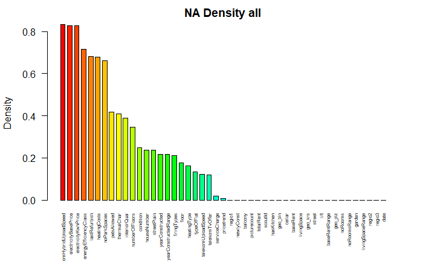

```r
#no_nas = apply(data_raw, MARGIN=2, function(x) {sum(is.na(x))})
no_nas = colSums(is.na(data_raw))
na_density = no_nas / nrow(data_raw)
na_density = na_density[order(na_density, decreasing = TRUE)]
barplot(na_density, main="NA Density all", ylab="Density", space=0.5,
        col = rainbow(length(na_density)), cex.names = 0.5, las=2)
```

It looks like there are some features without any data missing. Lets take a closer look at the more relevant features with more NA values.

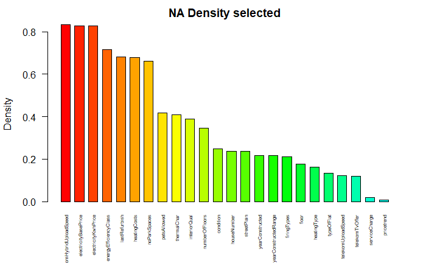

```r
no_na = which(na_density == 0)
many_na = na_density[-no_na]
barplot(many_na, main="NA Density selected", ylab="Density", space=0.5,
        col = rainbow(length(na_density)), cex.names = 0.5, las=2)
```

This is not looking too great. Many feature have a rather high NA density. As a rule of thumb I will try to impute features with a maximum NA density of 0.3. There are of course methods to impute way higher percentages but I dont want to spend too much time with advanced feature imputation methods(multiple imputations&regressions).

```r
na_remove_cols = which(na_density >= 0.3)
length(na_remove_cols)
```

```
[1] 11
```

```r
na_density[na_remove_cols]
```

```
telekomHybridUploadSpeed     electricityBasePrice      electricityKwhPrice    energyEfficiencyClass            lastRefurbish             heatingCosts             noParkSpaces
               0.8342202                0.8272041                0.8272041                0.7173295                0.6811455                0.6795645                0.6603688
             petsAllowed              thermalChar             interiorQual           numberOfFloors
               0.4176006                0.4105101                0.3893743                0.3475144
```

There are 11 features in question. Before blindly removing them by the arbitrary cutoff of 0.3 lets take a quick look on the features and if we still might want to keep them due to importance.

- telekomHybridUploadSpeed: probably not too important
- electricityBasePrice: sounds important but hard to guess
- electricityKwhPrice: same as for the base price, we could probably find this information online but would involve too much searching
- energyEfficiencyClass: as for the eletricity
- lastRefurbish: this sounds important and should correlate to the price. We might want to keep it even tho alot of data is missing.
- heatingCosts: important aswell and correlates to the EfficencyClass sadly too hard to guess and averaging would probably introduce too much of an bias
- noParkSpaces: prbably important, even more in non rural areas. We could assume that NA equals to no parkspaces and keep it.
- PetsAllowed: should not be too important especially since small pets are allowed by law anyways
- thermalCHar: directly relates to energyclass! could replace the information lost by droping the other columns and with 0.41 not remotely as bad as the other features.
- interiorQUal: seems important and also not too bad with ~0.39 missing values could just be imputed with “average condition”
- numberofFloors: seems to have an impact aswell so lets keep it.

To conclude it appears as if we should increase the “cutoff” to 0.4 to include most of the features discussed and include the ones above as exception.

```r
data_raw = subset(data_raw, select=-c(telekomHybridUploadSpeed,
                                      electricityBasePrice,
                                      energyEfficiencyClass,
                                      heatingCosts, petsAllowed))
head(data_raw)
```

|  | regio1 | serviceCharge | heatingType | telekomTvOffer | newlyConst | balcony | picturecount | pricetrend | telekomUploadSpeed | totalRent | yearConstructed | scoutId | noParkSpaces | firingTypes | hasKitchen | geo_bln | cellar | yearConstructedRange | baseRent | houseNumber | livingSpace | geo_krs | condition | interiorQual | street | streetPlain | lift | baseRentRange | typeOfFlat | … |
| --- | --- | --- | --- | --- | --- | --- | --- | --- | --- | --- | --- | --- | --- | --- | --- | --- | --- | --- | --- | --- | --- | --- | --- | --- | --- | --- | --- | --- | --- | --- |
| 1 | Nordrhein_Westfalen | 245 | central_heating | ONE_YEAR_FREE | FALSE | FALSE | 6 | 4.62 | 10.0 | 840.00 | 1965 | 96107057 | 1 | oil | FALSE | Nordrhein_Westfalen | TRUE | 2 | 595.00 | 244 | 86.00 | Dortmund | well_kept | normal | Sch&uuml;ruferstra&szlig;e | Schüruferstraße | FALSE | 4 | ground_floor | … |
| 3 | Sachsen | 255 | floor_heating | ONE_YEAR_FREE | TRUE | TRUE | 8 | 2.72 | 2.4 | 1300.00 | 2019 | 113147523 | 1 | NA | FALSE | Sachsen | TRUE | 9 | 965.00 | 4 | 83.80 | Dresden | first_time_use | sophisticated | Turnerweg | Turnerweg | TRUE | 6 | apartment | … |
| 5 | Bremen | 138 | self_contained_central_heating | NA | FALSE | TRUE | 19 | 2.46 | NA | 903.00 | 1950 | 114751222 | NA | gas | FALSE | Bremen | FALSE | 1 | 765.00 | 10 | 84.97 | Bremen | refurbished | NA | Hermann-Henrich-Meier-Allee | Hermann-Henrich-Meier-Allee | FALSE | 5 | apartment | … |
| 7 | Sachsen | 70 | self_contained_central_heating | ONE_YEAR_FREE | FALSE | FALSE | 9 | 1.01 | 2.4 | 380.00 | NA | 114391930 | NA | NA | FALSE | Sachsen | TRUE | NA | 310.00 | 14 | 62.00 | Mittelsachsen_Kreis | fully_renovated | NA | Am Bahnhof | Am_Bahnhof | FALSE | 2 | NA | … |
| 8 | Bremen | 88 | central_heating | ONE_YEAR_FREE | FALSE | TRUE | 5 | 1.89 | 2.4 | 584.25 | 1959 | 115270775 | NA | gas:electricity | FALSE | Bremen | TRUE | 2 | 452.25 | 35 | 60.30 | Bremen | NA | NA | Lesumer Heerstr. | Lesumer_Heerstr. | FALSE | 3 | ground_floor | … |
| 9 | Baden_Württemberg | 110 | oil_heating | ONE_YEAR_FREE | FALSE | FALSE | 5 | 3.77 | 40.0 | 690.00 | 1970 | 106416361 | 1 | oil | TRUE | Baden_Württemberg | TRUE | 2 | 580.00 | NA | 53.00 | Emmendingen_Kreis | well_kept | sophisticated | no_information | NA | FALSE | 4 | roof_storey | … |

# Feature and Target Analysis

I now will go over all columns to gain more insight into the data. I will start with the target “totalRent”.

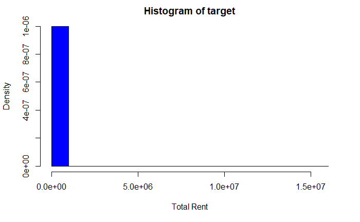

```r
target = data_raw$totalRent
hist(target, freq=FALSE, col="blue", xlab="Total Rent")
```

Apparently we have some extreme outliers lets check them out.

```r
target = sort(target, decreasing=TRUE)
head(target, 10)
```

```
 [1] 15751535  1234567  1150900  1000000   485350   108000    64651    63204    51570    37600
```

```r
tail(target, 10)
```

```
 [1] 0 0 0 0 0 0 0 0 0 0
```

Lets note: we have some extreme high rents which seem erroneous (1234567) but also some really low values or even 0. In the next step I will find out with how many outliers we are dealing with.

```r
high_rents = which(target > 20000)
low_rents = which(target < 200)
length(high_rents)
```

```
[1] 13
```

```r
length(low_rents)
```

```
[1] 670
```

Around 700. Not too bad we can just leave them out without reducing our data set significantly. I decided that monthly rents above 20.000e and below 200 seem unreasonable.

```r
remove_ind = c(high_rents, low_rents)
target = target[-remove_ind]
data_raw = data_raw[-remove_ind, ]
```

Lets check out the histogram again!

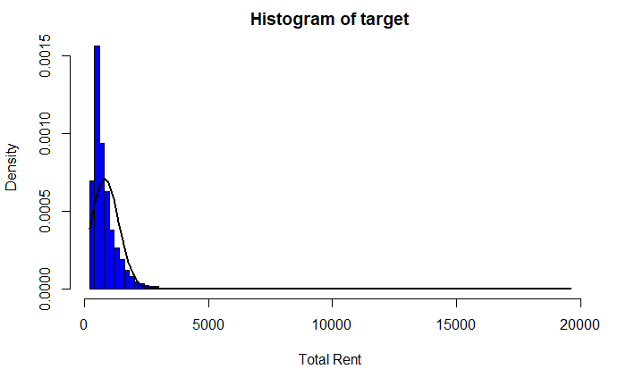

```r
hist(target, freq=FALSE, col="blue", xlab="Total Rent", breaks=100)
xdist = seq(min(target), max(target), length=100)
ydist = dnorm(xdist, mean(target), sd(target))
lines(xdist, ydist, col="black", lwd=2)
```

Still not good enough to get an idea of how our target distribution looks like. Lets cut this down further.(even a rent of 10k/month is really high!)

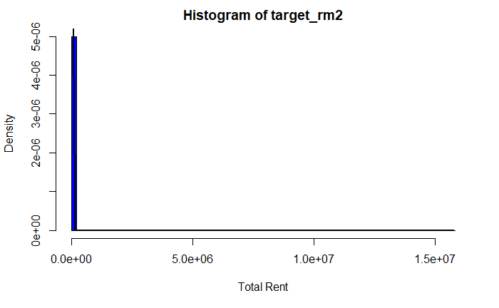

```r
remove_ind_2 = c(remove_ind_2, which(data_raw$totalRent < 200))
target_rm2 = data_raw$totalRent[-remove_ind_2]
hist(target_rm2, freq=FALSE, col="blue", xlab="Total Rent", breaks=100)
xdist = seq(min(target_rm2), max(target_rm2), length=100)
ydist = dnorm(xdist, mean(target_rm2), sd(target_rm2))
lines(xdist, ydist, col="black", lwd=2)
```

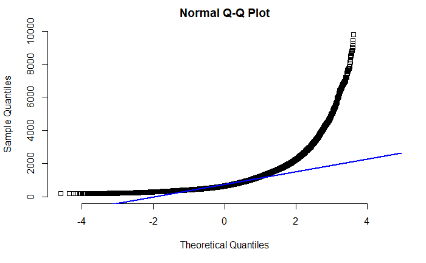

```r
qqnorm(target_rm2, pch=0.05, frame=FALSE, ylim=c(0, 10000))
qqline(target_rm2, col="blue", lwd=2)
```

```r
skew = skewness(target_rm2)
kur = kurtosis(target_rm2)
skew
```

```
[1] 465.149
```

```r
kur
```

```
[1] 219516
```

Lets take a look on a logarithmic scale

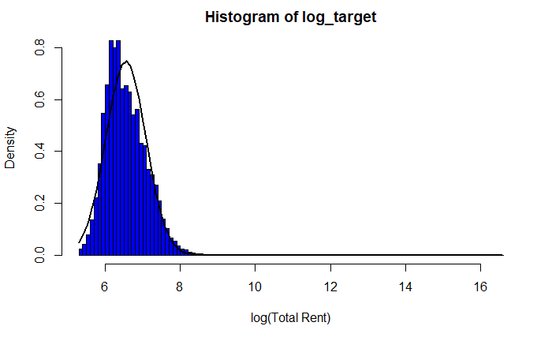

```r
log_target = log1p(target_rm2)
hist(log_target, freq=FALSE, col="blue", xlab="log(Total Rent)", breaks=100)
xdist = seq(min(log_target), max(log_target), length=100)
ydist = dnorm(xdist, mean(log_target), sd(log_target))
lines(xdist, ydist, col="black", lwd=2)
```

```r
skewness(log_target)
```

```
[1] 0.6564784
```

```r
kurtosis(log_target)
```

```
[1] 4.482281
```

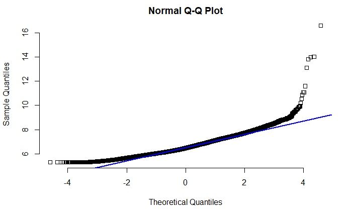

```r
qqnorm(log_target, pch=0.05, frame=FALSE)
qqline(log_target, col="blue", lwd=2)
```

Still not perfect but looks way better! Lets see if sqrt transform does any better.

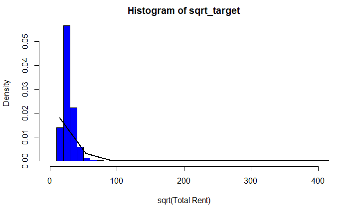

```r
sqrt_target = sqrt(target_rm2)
hist(sqrt_target, freq=FALSE, col="blue", xlab="sqrt(Total Rent)", breaks=300, xlim=c(0, 400))
xdist = seq(min(sqrt_target), max(sqrt_target), length=100)
ydist = dnorm(xdist, mean(sqrt_target), sd(sqrt_target))
lines(xdist, ydist, col="black", lwd=2)
```

```r
skewness(sqrt_target)
```

```
[1] 155.516
```

```r
kurtosis(sqrt_target)
```

```
[1] 47711.31
```

Nah this looks worse! Lets bring the big guns and use a Box-Cox transform

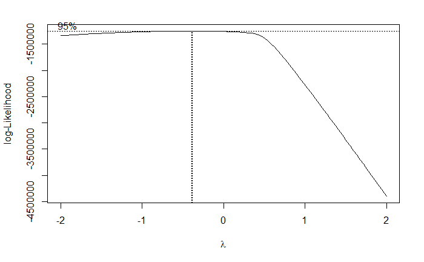

```r
bc_model = MASS::boxcox((lm(target_rm2 ~ 1)))
```

```r
lambda = bc_model$x[which.max(bc_model$y)]
lambda
```

```
[1] -0.3838384
```

Our perfect value for lambda is about -0.384! Lets transform

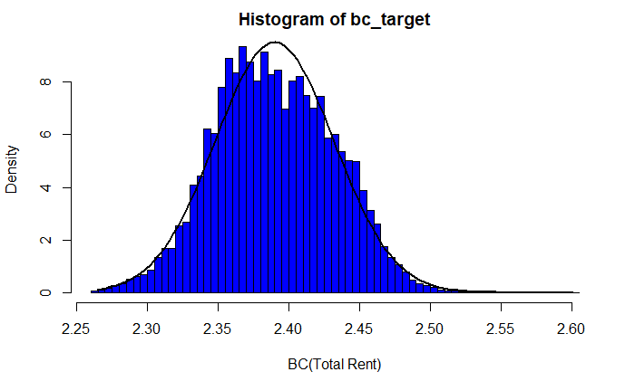

```r
bc_target = (target_rm2 ** lambda - 1) / lambda
hist(bc_target, freq=FALSE, col="blue", xlab="BC(Total Rent)", breaks=100)
xdist = seq(min(bc_target), max(bc_target), length=100)
ydist = dnorm(xdist, mean(bc_target), sd(bc_target))
lines(xdist, ydist, col="black", lwd=2)
```

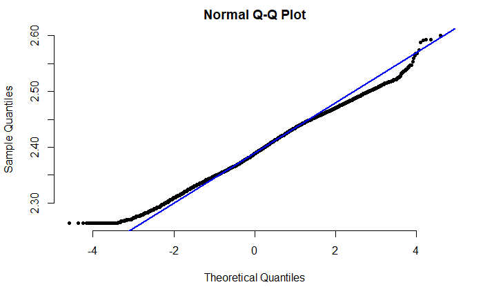

```r
qqnorm(bc_target, pch=20, frame=FALSE)
qqline(bc_target, col="blue", lwd=2)
```

```r
skewness(bc_target)
```

```
[1] 0.04692689
```

```r
kurtosis(bc_target)
```

```
[1] 2.647168
```

This looks promissing! Lets keep the log1p transformation in mind and use this one for now!

```r
#data_raw$totalRent = log1p(data_raw$totalRent)
data_raw = data_raw[-remove_ind_2, ]
data_raw$totalRent = bc_target
```

Lets now get over the features one by one, transform possibly categorical variables and fill in the NA’s

```r
names(data_raw)
```

```
 [1] "regio1"               "serviceCharge"        "heatingType"          "telekomTvOffer"       "newlyConst"           "balcony"              "picturecount"
 [8] "pricetrend"           "telekomUploadSpeed"   "totalRent"            "yearConstructed"      "scoutId"              "noParkSpaces"         "firingTypes"
[15] "hasKitchen"           "geo_bln"              "cellar"               "yearConstructedRange" "baseRent"             "houseNumber"          "livingSpace"
[22] "geo_krs"              "condition"            "interiorQual"         "street"               "streetPlain"          "lift"                 "baseRentRange"
[29] "typeOfFlat"           "geo_plz"              "noRooms"              "thermalChar"          "floor"                "numberOfFloors"       "noRoomsRange"
[36] "garden"               "livingSpaceRange"     "regio2"               "regio3"               "lastRefurbish"        "electricityKwhPrice"  "date"
```

```r
no_nas_updated = colSums(is.na(data_raw))
row_nas = rowSums(is.na(data_raw))
```

### regio1

```r
temp = data_raw$regio1
head(temp, 10)
```

```
 [1] "Sachsen"            "Niedersachsen"      "Schleswig_Holstein" "Baden_WÃ¼rttemberg" "Sachsen"            "Bayern"             "Hamburg"            "Niedersachsen"
 [9] "Baden_WÃ¼rttemberg" "Sachsen_Anhalt"
```

regio1 appears to give information about the “Bundesland” - We can simply encode these.

```r
unique(temp)
```

```
 [1] "Sachsen"                "Niedersachsen"          "Schleswig_Holstein"     "Baden_WÃ¼rttemberg"     "Bayern"                 "Hamburg"                "Sachsen_Anhalt"
 [8] "Mecklenburg_Vorpommern" "Nordrhein_Westfalen"    "Hessen"                 "Berlin"                 "Brandenburg"            "Bremen"                 "Rheinland_Pfalz"
[15] "ThÃ¼ringen"             "Saarland"
```

Good news! No NA’s we have to deal with.

```r
which(is.na(temp))
```

```
integer(0)
```

lets convert to our dummy variable

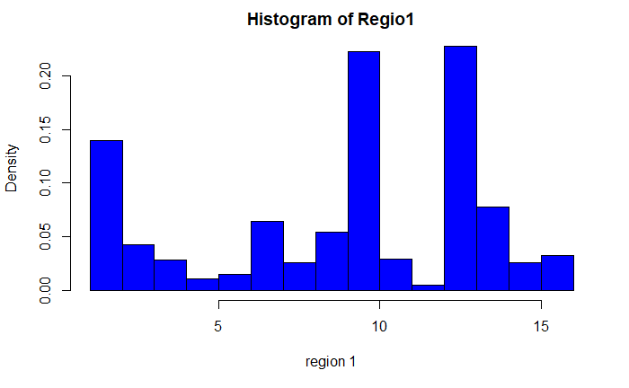

```r
temp = as.numeric(as.character(factor(temp, labels = 1:length(unique(temp)))))

hist(temp, col="blue", main="Histogram of Regio1", breaks=length(unique(temp))
     , freq = FALSE, xlab="region 1")
```

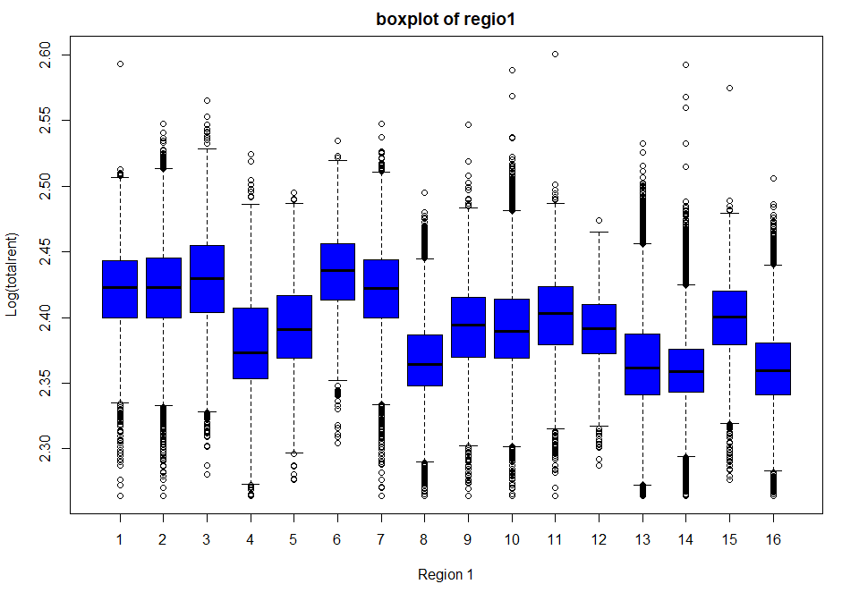

```r
boxplot(data_raw$totalRent~temp, col="blue", stroke="red",
        main="boxplot of regio1", xlab = "Region 1", ylab="Log(totalrent)")
```

```r
data_raw$regio1 = temp
```

### regio2

```r
temp = data_raw$regio2
head(temp, 10)
```

```
 [1] "Mittelsachsen_Kreis" "GÃ¶ttingen_Kreis"    "NeumÃ¼nster"         "Stuttgart"           "Leipzig"             "MÃ¼nchen"            "Hamburg"             "Braunschweig"
 [9] "Esslingen_Kreis"     "Magdeburg"
```

regio2 seems to narrow the geolocation further down to the city level.

```r
length(unique(temp))
```

```
[1] 419
```

```r
which(is.na(temp))
```

```
integer(0)
```

great no NA’s here again.

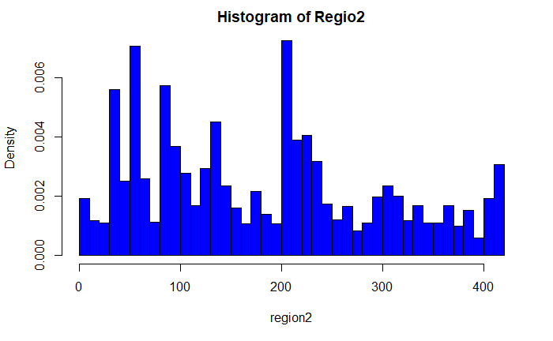

```r
temp = as.numeric(as.character(factor(temp, labels = 1:length(unique(temp)))))

hist(temp, col="blue", main="Histogram of Regio2", breaks=50, freq = FALSE,
     xlab="region2")
```

```r
data_raw$regio2 = temp
```

### regio3

```r
temp = data_raw$regio3
head(temp, 10)
```

```
 [1] "DÃ¶beln"               "GÃ¶ttingen"            "Wittorf"               "Bad_Cannstatt"         "Lindenau"              "Altstadt"              "Horn"
 [8] "Westliches_Ringgebiet" "NÃ¼rtingen"            "Kannenstieg"
```

regio2 seems to narrow the geolocation further down to the precise location.

```r
length(unique(temp))
```

```
[1] 8331
```

```r
which(is.na(temp))
```

```
integer(0)
```

Due to the size of the data set I dont see that drilling down to this level will be beneficial since there are not too many points per location to go by. Thus we drop this column.

```r
data_raw = subset(data_raw, selec=-c(regio3))
```

### servicecharge

```r
temp = data_raw$serviceCharge
head(temp, 10)
```

```
 [1]  50.00 290.00 140.00   0.00 346.00 180.00 140.00  80.00  20.00 147.32
```

These seem to be the side-costs for maintenence and service.

```r
length(which(is.na(temp)))
```

```
[1] 4022
```

It appears as if we still have some NA’s here. I will impute the average over each regio1 for the missing values.

```r
averages = aggregate(temp, list(data_raw$regio1), mean, na.rm=TRUE)



for (i in which(is.na(temp))){
  for (j in 1:length(unique(data_raw$regio1))){
    if (data_raw$regio1[i] == j){
      temp[i] = averages[j, 2]
    }
  }
}

sum(is.na(temp))
```

```
[1] 0
```

Now that we filled missing values lets plot them vs the rent

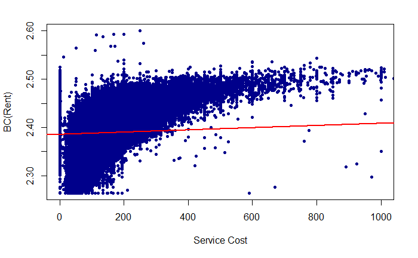

```r
plot(temp, data_raw$totalRent, type = "p", xlim = c(0, 1000),
     pch=20, col="darkblue", xlab="Service Cost", ylab="BC(Rent)")
temp_model = lm(data_raw$totalRent~temp)
abline(temp_model, col="red", lwd=2)
```

Note OLS linear regression is sensitive to outliers. -> use robust regression methods as propper model. (even tho it seems as if a linear model is not what we see here more like log)

```r
summary(temp_model)
```

```
Call:
lm(formula = data_raw$totalRent ~ temp)

Residuals:
    Min      1Q  Median      3Q     Max
-3.2299 -0.0295 -0.0014  0.0299  0.2087

Coefficients:
             Estimate Std. Error  t value Pr(>|t|)
(Intercept) 2.387e+00  9.564e-05 24952.97   <2e-16 ***
temp        2.223e-05  2.671e-07    83.21   <2e-16 ***
---
Signif. codes:  0 ‘***’ 0.001 ‘**’ 0.01 ‘*’ 0.05 ‘.’ 0.1 ‘ ’ 1

Residual standard error: 0.04127 on 226946 degrees of freedom
Multiple R-squared:  0.0296,    Adjusted R-squared:  0.0296
F-statistic:  6924 on 1 and 226946 DF,  p-value: < 2.2e-16
```

```r
data_raw$serviceCharge = temp
```

### heatingtype

```r
temp = data_raw$heatingType
head(temp, 10)
```

```
 [1] "central_heating"  "district_heating" "central_heating"  NA                 "central_heating"  "central_heating"  "central_heating"  "district_heating" NA
[10] "district_heating"
```

heatingType gives information about the heating -duh. Another Categorical Variable!

```r
unique(temp)
```

```
 [1] "central_heating"                "district_heating"               NA                               "floor_heating"                  "wood_pellet_heating"
 [6] "oil_heating"                    "gas_heating"                    "self_contained_central_heating" "electric_heating"               "combined_heat_and_power_plant"
[11] "heat_pump"                      "night_storage_heater"           "stove_heating"                  "solar_heating"
```

```r
sum(is.na(temp))
```

```
[1] 36605
```

Since we dont know the heating we will introduce a new category “other” for the NA’s. Another possibility it to use the most common heating.

```r
temp[is.na(temp)] = "other"
temp = as.numeric(as.character(factor(temp, labels = 1:length(unique(temp)))))
```

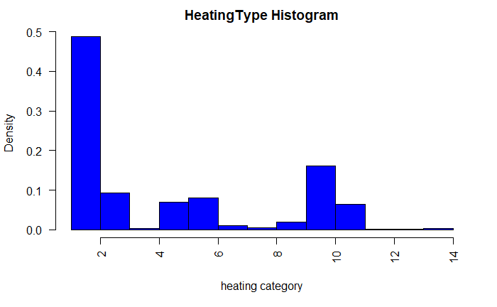

```r
hist(temp, las=2, freq = FALSE, col="blue", xlab="heating category",
     main="HeatingType Histogram", breaks = length(unique(temp)))
```

We see that most buildings fall into the heating Category 1. Instead of introducing other we could have just assumed the NA’s to be of the same type or randomly draw from the distribution. To improve performance we might come back to this later.

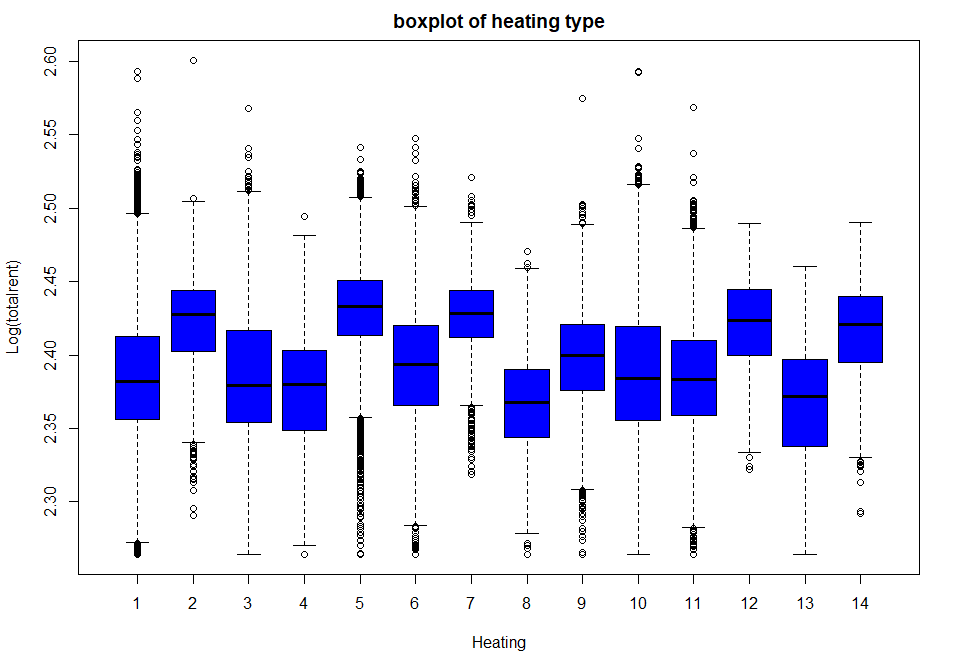

```r
boxplot(data_raw$totalRent~temp, col="blue", stroke="red",
        main="boxplot of heating type", xlab = "Heating", ylab="Log(totalrent)")
```

```r
data_raw$heatingType = temp
```

### telekomTvOffer

```r
temp = data_raw$telekomTvOffer
head(temp, 10)
```

```
 [1] "ONE_YEAR_FREE" "ONE_YEAR_FREE" "ONE_YEAR_FREE" "ONE_YEAR_FREE" "ONE_YEAR_FREE" "ONE_YEAR_FREE" "ONE_YEAR_FREE" "ONE_YEAR_FREE" "ONE_YEAR_FREE" "ONE_YEAR_FREE"
```

```r
unique(temp)
```

```
[1] "ONE_YEAR_FREE" NA              "NONE"          "ON_DEMAND"
```

This features tells us about the telekom TV offers for the flat. it apparently has 4 possible values including NA. Lets look at the histogram fist before deciding what to do with NA’s.

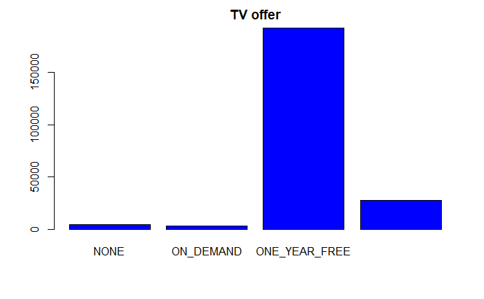

```r
plot(factor(temp, exclude=NULL), col="blue", main="TV offer")
```

We see that almost all buildings get the one year free option. This feature will probably not be too interesting but lets add the NA’s to this category for now and decide later if we are going to use it or not.

```r
temp[is.na(temp)] = "ONE_YEAR_FREE"
temp = as.numeric(as.character(factor(temp, labels = 1:length(unique(temp)))))
data_raw$telekomTvOffer = temp
```

### newlyConnst

```r
temp = data_raw$newlyConst
head(temp, 10)
```

```
 [1] FALSE FALSE FALSE FALSE FALSE FALSE FALSE FALSE FALSE FALSE
```

```r
unique(temp)
```

```
[1] FALSE  TRUE
```

This is great we do not have any NA’s and this appears to be a bloolean Variable telling us if a building was newly constructed or not. Lets check the weight of the two categories.

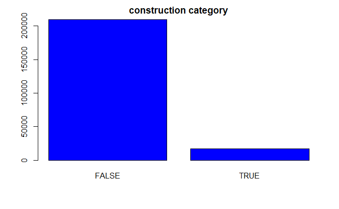

```r
plot(as.factor(temp), col="blue", main="construction category")
```

Apparently most buildings are not new, as was to be expected. I am just going to enncode this as True = 1 False = 0

```r
temp = ifelse(temp == FALSE, 0, 1)
```

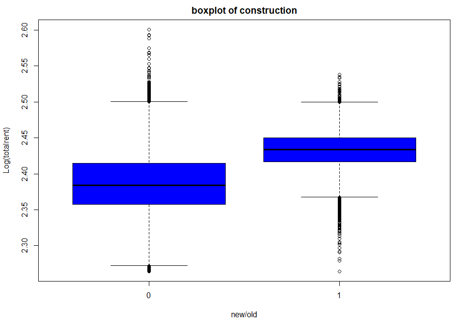

```r
boxplot(data_raw$totalRent~temp, col="blue", stroke="red",
        main="boxplot of construction", xlab = "new/old",
        ylab="Log(totalrent)")
```

The trend is that new flats rent for more then old ones. Not too surprising either.

```r
data_raw$newlyConst = temp
```

### balcony

```r
temp = data_raw$balcony
head(temp, 10)
```

```
 [1] FALSE  TRUE  TRUE FALSE  TRUE FALSE  TRUE FALSE FALSE  TRUE
```

```r
unique(temp)
```

```
[1] FALSE  TRUE
```

This feature is rather self explanatory. Boolean variable if a flat has a balcony or not.

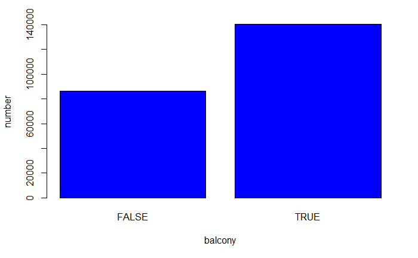

```r
plot(as.factor(temp), col="blue", xlab="balcony", ylab="number")
```

This is surprising! Most flats actually do have a balcony. Lets encode in the same fashion.

```r
temp = ifelse(temp == FALSE, 0, 1)
```

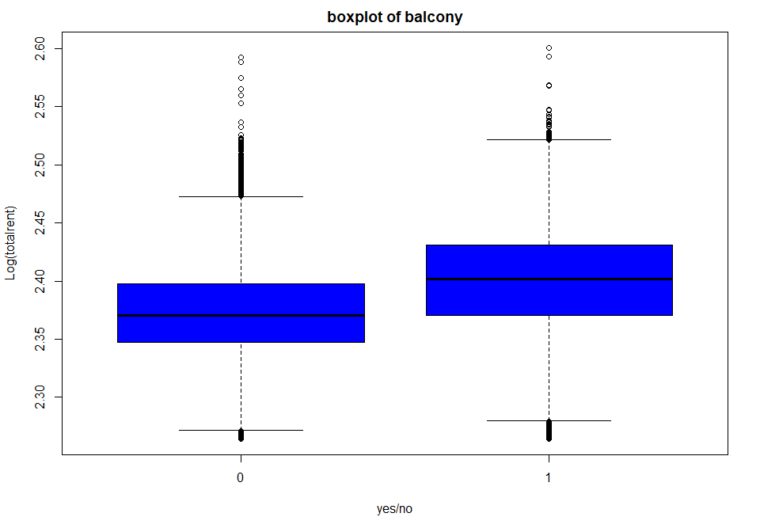

```r
boxplot(data_raw$totalRent~temp, col="blue", stroke="red",
        main="boxplot of balcony", xlab = "yes/no", ylab="Log(totalrent)")
```

This looks promising. Price for flats with a balcony are slightly higher in the log presentation as flats without.

```r
data_raw$balcony = temp
```

### picturecount

```r
temp = data_raw$picturecount
head(temp, 10)
```

```
 [1] 12 35 15 13 22 18  9  7  7 14
```

The picturecount feature refers to the number of pictures of the flat in the expose listed.

```r
sum(is.na(temp))
```

```
[1] 0
```

No missing data, great.

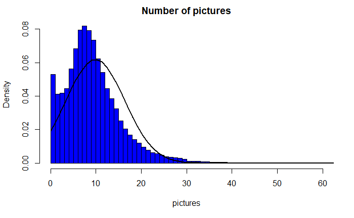

```r
hist(temp, col="blue", breaks = length(unique(temp)), main="Number of pictures",
     xlab="pictures", xlim=c(0, 60), freq=FALSE)
xdist = seq(min(temp), max(temp), length=100)
ydist = dnorm(xdist, mean(temp), sd(temp))
lines(xdist, ydist, col="black", lwd=2)
```

The distribution does not quite follow a normal distirbution with a strong right tail and outliers at low values.

Lets see if our number of pictures is correlated to the BC(totalRent). As a meassure I am going to perform the Spearmans-Correlation-Test. This is somewhat to Pearsons correlation but describes not a linear but a monotonic relation. The Spearman correlation between two variables is equal to the Pearson correlation between the rank values of those two variables.

```r
corr_spear = cor.test(temp, data_raw$totalRent, method="spearman", exact=FALSE)
corr_spear
```

```
    Spearman's rank correlation rho

data:  temp and data_raw$totalRent
S = 1.3849e+15, p-value < 2.2e-16
alternative hypothesis: true rho is not equal to 0
sample estimates:
      rho
0.2891153
```

With a p-value of about 0 we accept the alternative hypothesis. There is a positive correlation between the two variables. With a rho of ~0.29 the correlation is rather low.

### pricetrend

```r
temp = data_raw$pricetrend
head(temp, 10)
```

```
 [1] 1.96 2.35 5.00 5.63 5.34 4.47 6.30 0.59 4.65 1.08
```

This reflects a metric calculated by Immoscout.

```r
sum(is.na(temp))
```

```
[1] 1599
```

We do need to impute some values. To do so we will use the same strategy as employed for the servicecharge feature.

```r
averages = aggregate(temp, list(data_raw$regio1), mean, na.rm=TRUE)



for (i in which(is.na(temp))){
  for (j in 1:length(unique(data_raw$regio1))){
    if (data_raw$regio1[i] == j){
      temp[i] = averages[j, 2]
    }
  }
}

sum(is.na(temp))
```

```
[1] 0
```

Lets visualize!

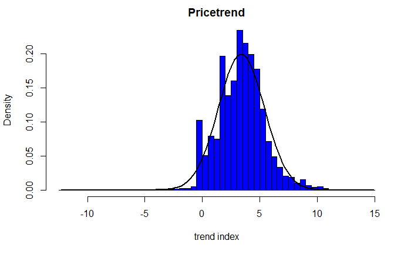

```r
hist(temp, col="blue", main="Pricetrend", xlab="trend index", freq=FALSE, breaks=50)
xdist = seq(min(temp), max(temp), length=100)
ydist = dnorm(xdist, mean(temp), sd(temp))
lines(xdist, ydist, col="black", lwd=2)
```

This looks rather normal. Interesting!

```r
skewness(temp)
```

```
[1] 0.4014964
```

```r
kurtosis(temp)
```

```
[1] 3.752084
```

Lets see if the trend correlates with the price.

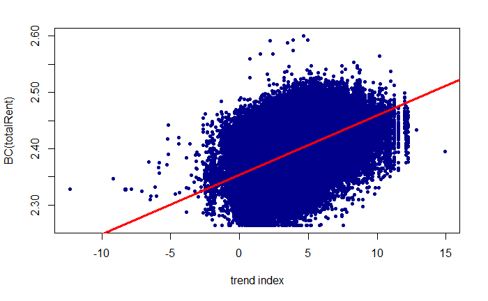

```r
plot(temp, data_raw$totalRent, xlab="trend index", ylab="BC(totalRent)", col="darkblue", pch=20)
temp_model = lm(data_raw$totalRent~temp)
abline(temp_model, col="red", lwd=3)
```

```r
summary(temp_model)
```

```
Call:
lm(formula = data_raw$totalRent ~ temp)

Residuals:
      Min        1Q    Median        3Q       Max
-0.169295 -0.023987 -0.000732  0.024581  0.214820

Coefficients:
             Estimate Std. Error t value Pr(>|t|)
(Intercept) 2.354e+00  1.501e-04 15679.5   <2e-16 ***
temp        1.054e-02  3.808e-05   276.8   <2e-16 ***
---
Signif. codes:  0 ‘***’ 0.001 ‘**’ 0.01 ‘*’ 0.05 ‘.’ 0.1 ‘ ’ 1

Residual standard error: 0.03622 on 226946 degrees of freedom
Multiple R-squared:  0.2524,    Adjusted R-squared:  0.2524
F-statistic: 7.663e+04 on 1 and 226946 DF,  p-value: < 2.2e-16
```

```r
corr = cor.test(temp, data_raw$totalRent, method="pearson")
corr
```

```
    Pearson's product-moment correlation

data:  temp and data_raw$totalRent
t = 276.82, df = 226946, p-value < 2.2e-16
alternative hypothesis: true correlation is not equal to 0
95 percent confidence interval:
 0.4993308 0.5054823
sample estimates:
      cor
0.5024129
```

We do have some outliers but there is a medium(0.50) positive correlation between these two.

```r
data_raw$pricetrend = temp
```

### telekomUploadSpeed

```r
temp = data_raw$telekomUploadSpeed
head(temp, 10)
```

```
 [1] 40  5 10 40 40 10 40 40 10 40
```

This feature should give information about the possible internet speed available at the location.

```r
sum(is.na(temp))
```

```
[1] 27871
```

We use the same imputation strategy.

```r
averages = aggregate(temp, list(data_raw$regio1), mean, na.rm=TRUE)



for (i in which(is.na(temp))){
  for (j in 1:length(unique(data_raw$regio1))){
    if (data_raw$regio1[i] == j){
      temp[i] = averages[j, 2]
    }
  }
}

sum(is.na(temp))
```

```
[1] 0
```

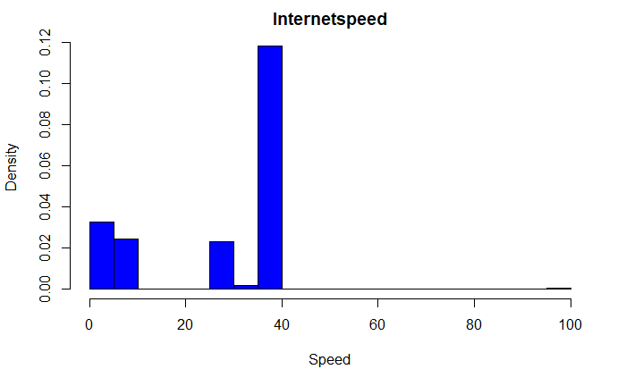

```r
hist(temp, col="blue", main="Internetspeed", xlab="Speed", freq=FALSE, breaks=length(unique(temp)))
```

```r
unique(temp)
```

```
 [1]  40.00000   5.00000  10.00000   2.40000  27.27293  32.27317  28.82554  29.15811  29.56724  28.96933  26.77870  29.92131  27.86535  34.18129  27.64964  26.93006  29.21366
[18]  29.18222 100.00000   1.00000  26.02064  25.48891   4.00000
```

So most people have internetspeed of about 40 with some people below that and just a few people above.

```r
data_raw$telekomUploadSpeed = temp
```

### yearConstructed

```r
temp = data_raw$yearConstructed
head(temp, 10)
```

```
 [1] 1897 2013 1978   NA   NA 1871 1953 1890 1902 1977
```

```r
sum(is.na(temp)) / length(temp)
```

```
[1] 0.2157366
```

```r
sum(is.na(temp))
```

```
[1] 48961
```

So we have to impute data for roughly 22% of the buildings. Since I think the construction year does impact the rental cost strongly we have to be careful with the way how we impute them. Instead of averaging over the regio1 data we will go the further step and average over regio2 since it is to be expected that buildings in the same area were built at roughly the same time.

```r
averages = aggregate(temp, list(data_raw$regio2), mean, na.rm=TRUE)



for (i in which(is.na(temp))){
  for (j in 1:length(unique(data_raw$regio2))){
    if (data_raw$regio2[i] == j){
      temp[i] = averages[j, 2]
    }
  }
}

sum(is.na(temp))
```

```
[1] 0
```

I am only interested in whole years(integers) so lets round them

```r
temp = round(temp)
```

Lets sneak a peak into the distribution

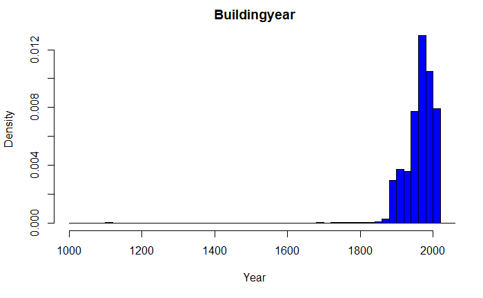

```r
hist(temp, col="blue", main="Buildingyear", xlab="Year", freq=FALSE, breaks=75,  xlim=c(1000, 2020))
```

So far nothing too surprising.

```r
median(temp)
```

```
[1] 1970
```

```r
temp[temp<1500]
```

```
  [1] 1111 1111 1111 1111 1280 1111 1111 1111 1111 1400 1111 1365 1375 1111 1111 1111 1430 1111 1111 1460 1111 1300 1111 1111 1111 1400 1200 1355 1111 1480 1111 1395 1111 1450 1111
 [36] 1111 1190 1180 1200 1111 1111 1111 1111 1111 1111 1111 1460 1078 1197 1036 1111 1111 1111 1193 1111 1111 1111 1359 1111 1111 1027 1331 1378 1111 1300 1111 1111 1000 1111 1097
 [71] 1111 1111 1111 1111 1111 1111 1194 1111 1063 1111 1195 1111 1111 1475 1111 1005 1111 1111 1111 1111 1111 1450 1111 1111 1491 1111 1111 1111 1111 1111 1300 1400 1380 1370 1471
[106] 1111 1111 1111 1111 1191 1470 1111 1390 1111 1111 1198 1070 1111 1276 1111 1300 1111 1404 1111 1111 1111 1111 1196 1111 1111 1111 1440 1111 1111 1472 1111 1111 1111
```

So apparently the median building year was 1970. Surprisingly there are actually quite many buildings from the year 1111 which I am rather suspicious about. After some online searches these buildings are clearly not over 1000 years old. I am just going to remove any house with an age over 500 which in my eyes is simply not realistic to encounter.

```r
data_raw[which(data_raw$yearConstructed==1111),]
```

|  | regio1 | serviceCharge | heatingType | telekomTvOffer | newlyConst | balcony | picturecount | pricetrend | telekomUploadSpeed | totalRent | yearConstructed | scoutId | noParkSpaces | firingTypes | hasKitchen | geo_bln | cellar | yearConstructedRange | baseRent | houseNumber | livingSpace | geo_krs | condition | interiorQual | street | streetPlain | lift | baseRentRange | typeOfFlat | … |
| --- | --- | --- | --- | --- | --- | --- | --- | --- | --- | --- | --- | --- | --- | --- | --- | --- | --- | --- | --- | --- | --- | --- | --- | --- | --- | --- | --- | --- | --- | --- |
| 2153 | 10 | 109.00 | 1 | 3 | 0 | 0 | 7 | 3.45 | 40.00000 | 2.378725 | 1111 | 115538262 | NA | NA | FALSE | Nordrhein_Westfalen | TRUE | 1 | 415.00 | 6 | 59.14 | Duisburg | NA | NA | Henschelstr. | Henschelstr. | FALSE | 3 | apartment | … |
| 2542 | 13 | 53.50 | 1 | 3 | 0 | 1 | 7 | 3.00 | 29.56724 | 2.342093 | 1111 | 115267331 | NA | NA | FALSE | Sachsen | TRUE | 1 | 290.00 | 9 | 49.50 | Leipzig | NA | NA | Giordano-Bruno-Stra&szlig;e | Giordano-Bruno-Straße | FALSE | 1 | roof_storey | … |
| 7605 | 13 | 68.00 | 11 | 3 | 0 | 1 | 7 | 3.87 | 40.00000 | 2.338296 | 1111 | 115555925 | NA | NA | FALSE | Sachsen | TRUE | 1 | 310.12 | 2 | 50.84 | Leipzig | NA | NA | Burgst&auml;dter Str. | Burgstädter_Str. | FALSE | 2 | apartment | … |
| 8818 | 10 | 89.00 | 1 | 3 | 0 | 1 | 4 | 4.66 | 40.00000 | 2.397320 | 1111 | 115627128 | NA | NA | FALSE | Nordrhein_Westfalen | TRUE | 1 | 555.00 | 17 | 66.92 | Bochum | NA | NA | Andreas-Hofer-Str. | Andreas-Hofer-Str. | FALSE | 4 | apartment | … |
| 11924 | 13 | 75.00 | 1 | 3 | 0 | 1 | 8 | 1.72 | 40.00000 | 2.376900 | 1111 | 114929482 | NA | NA | FALSE | Sachsen | TRUE | 1 | 433.00 | 41b | 58.58 | Dresden | NA | NA | Grillparzerstr. | Grillparzerstr. | FALSE | 3 | apartment | … |
| 12691 | 13 | 83.00 | 1 | 3 | 0 | 0 | 3 | 1.73 | 40.00000 | 2.365260 | 1111 | 115686741 | NA | NA | FALSE | Sachsen | TRUE | 1 | 361.00 | 31 | 55.08 | Dresden | NA | NA | Grunaer Str. | Grunaer_Str. | FALSE | 2 | apartment | … |
| 16805 | 13 | 98.00 | 1 | 3 | 0 | 1 | 3 | 3.91 | 40.00000 | 2.396209 | 1111 | 115705124 | NA | NA | FALSE | Sachsen | TRUE | 1 | 535.00 | 10 | 85.28 | Leipzig | NA | NA | Mascovstra&szlig;e | Mascovstraße | FALSE | 4 | apartment | … |
| 17216 | 13 | 74.00 | 1 | 3 | 0 | 0 | 6 | 2.08 | 40.00000 | 2.369549 | 1111 | 115087624 | NA | NA | FALSE | Sachsen | TRUE | 1 | 390.00 | 15 | 59.38 | Dresden | NA | NA | Bunsenstra&szlig;e | Bunsenstraße | FALSE | 2 | apartment | … |
| 22047 | 13 | 109.00 | 1 | 3 | 0 | 1 | 3 | 4.82 | 40.00000 | 2.370835 | 1111 | 115705122 | NA | NA | FALSE | Sachsen | TRUE | 1 | 394.51 | 5 | 65.19 | Leipzig | NA | NA | Henriettenstra&szlig;e | Henriettenstraße | FALSE | 2 | apartment | … |
| 24098 | 10 | 145.00 | 1 | 3 | 0 | 0 | 10 | 2.52 | 40.00000 | 2.363447 | 1111 | 112789910 | NA | NA | FALSE | Nordrhein_Westfalen | TRUE | 1 | 284.31 | 17 | 63.51 | Recklinghausen_Kreis | NA | NA | Geschwisterstr. | Geschwisterstr. | FALSE | 1 | roof_storey | … |

[output cut: 77 more lines]

```r
head(sort(data_raw$yearConstructed), 50)
```

```
 [1] 1000 1005 1027 1036 1063 1070 1078 1097 1111 1111 1111 1111 1111 1111 1111 1111 1111 1111 1111 1111 1111 1111 1111 1111 1111 1111 1111 1111 1111 1111 1111 1111 1111 1111 1111
[36] 1111 1111 1111 1111 1111 1111 1111 1111 1111 1111 1111 1111 1111 1111 1111
```

```r
remove_ind = which(temp<1500)
```

```r
temp = temp[-remove_ind]
```

```r
cor.test(temp, data_raw$totalRent[-remove_ind])
```

```
    Pearson's product-moment correlation

data:  temp and data_raw$totalRent[-remove_ind]
t = 99.311, df = 227559, p-value < 2.2e-16
alternative hypothesis: true correlation is not equal to 0
95 percent confidence interval:
 0.199875 0.207751
sample estimates:
      cor
0.2038163
```

```r
data_raw = data_raw[-remove_ind, ]
data_raw$yearConstructed = temp
```

### scoutid

```r
temp = data_raw$scoutId
head(temp, 10)
```

```
 [1] 107018003 113019528 110416311 113836264 111412293 113626688 111337159 115506913 115403430 114132653
```

This appears to be the ID of the ad. Should not hold any meaning so we can drop it.

```r
data_raw = subset(data_raw, select=-c(scoutId))
```

### noParkSpaces

```r
temp = data_raw$noParkSpaces
head(temp, 10)
```

```
 [1] NA  1  2 NA NA NA NA NA NA NA
```

Here we see how many parkingspaces are connected to a given flat. One could assume that one - or even more - spaces would result in a higher rent! Since we already established that there are some NA values we will assume from here on that no information about a parkingspace means there is none.

```r
unique(temp)
```

```
 [1]  NA   1   2  27   0   3   4  25  31  30  12  50  18  48  22   5  15  46  80  13  26  19  20  24  33   8 150  60   6   9  10  65  11  95  75  16 130  93  14  40  36   7  17  82
[45]  23  38  90  85  21  39  28  45  64  54  87  55  34 320  35  99  70  76  59  37  73 310  58
```

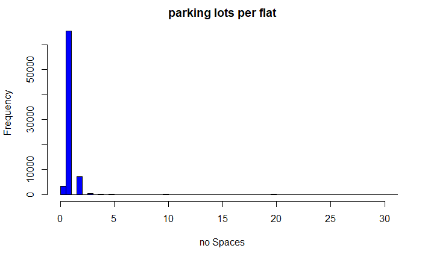

```r
hist(temp[!is.na(temp)], breaks=500, col="blue", xlim=c(0, 30), xlab="no Spaces", main="parking lots per flat")
```

Apparently most flats with a parking space do have one. This is not surprising. More worrying is that we have some flats with double or even triple digits. This does not seem right lets see with how many samples we are dealing with.

```r
length(which(temp > 10))
```

```
[1] 482
```

```r
remove_ind = which(temp > 10)
temp = temp[-remove_ind]
temp[is.na(temp)] = 0
```

Lets check out the distribution again

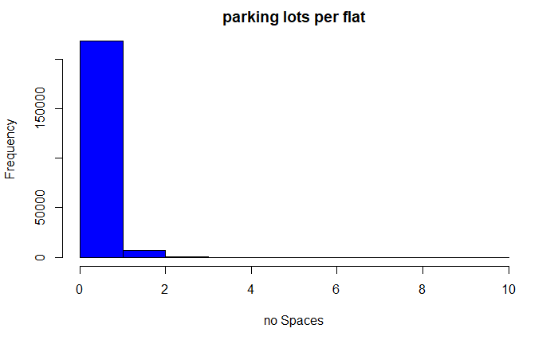

```r
hist(temp, breaks=length(unique(temp)), col="blue", xlab="no Spaces", main="parking lots per flat")
```

So most flats do not come with a parking space.

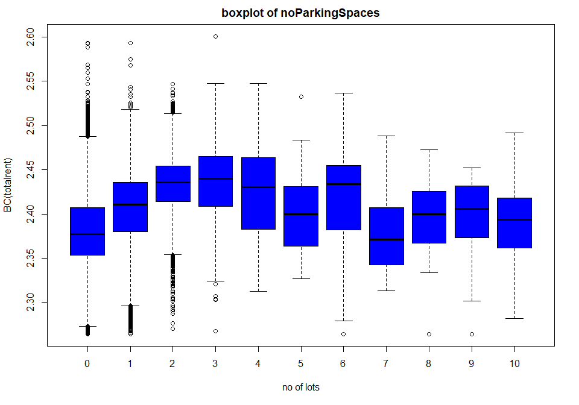

```r
boxplot(data_raw$totalRent[-remove_ind]~temp, col="blue", stroke="red",
        main="boxplot of noParkingSpaces", xlab = "no of lots", ylab="BC(totalrent)")
```

This confirms our assumption that in general flats with a parking lot are more expensive - even though there are of course flats with no parkingspace which are more expensive.

```r
data_raw = data_raw[-remove_ind, ]
data_raw$noParkSpaces = temp
```